# Region-Specific Emission Targets

How to define region-specific emission targets, either as year-based targets or emission budgets:

### Setting Emission Targets: `cm_emiMktTarget`

- require `regipol` to be set to `regiCarbonPrice`

### Options

| **Option** | **Description** |
| --- | --- |
| `off` | No regional emission target |
| `scenario_tag` | Targets defined in module 47 declarations under the scenario tag |
| `2020.2050.EU27_regi.all.budget.netGHG_noBunkers 72` | Explicitly defined target configuration |

### CO2 Tax Curve Shape

| **Segment** | **Description** |
| --- | --- |
| Pre-target years | Linear increase from the starting year (`initial_year`) to the target year (`target_year`) |
| Post-target years | Annual increase based on the `cm_postTargetIncrease` value (in EUR per tCO2) |

### EU-27 target example (Germany and EU-27)

1. fixed historical value
2. EU-27 57% reduction: `2020.2030.EU27_regi.all.year.netGHG_LULUCFGrassi_intraRegBunker 2.191`  
   and DEU 65% reduction: `2020.2030.DEU.all.year.netGHG_noLULUCF_noBunkers 0.42`
3. effect of DEU 2045 net-neutral target on EU-27 aggregated price: `2035.2045.DEU.all.year.netGHG_LULUCFGrassi 0.0001`
4. EU-27 net-neutral 2050 target: `2020.2050.EU27.all.year.netGHG_LULUCFGrassi 0.0001`

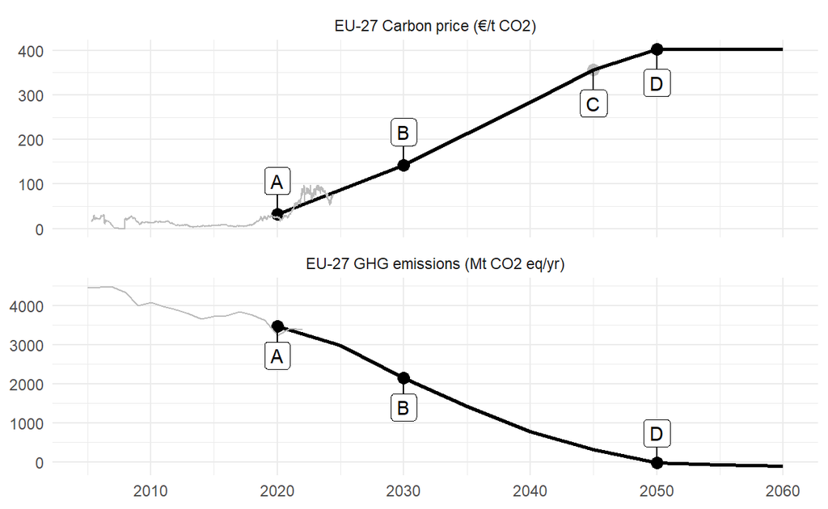

### Examples

[output not shown]

### Emission Target Definition

`cm_emiMktTarget` follows this format:

`initial_year`.`target_year`.`region`.`group_of_sectors`.`type_of_target`.`emissions_type` `value`

### Configuration Parameters

| **Parameter** | **Set** | **Values** | **Description** |
| --- | --- | --- | --- |
| `initial_year` | `ttot` | year with four digits | Year when price increase starts and budget calculation begins |
| `target_year` | `ttot` | year with four digits | Year when the emission target or budget is achieved |
| `region` | `ext_reg` | ISO3 code or REMIND region code | Region where the target applies |
| `group_of_sectors` | `emiMktExt` | `all`, `ETS`, `ESR`, `other` | Targeted emission markets: all emissions, ETS market, Effort Sharing market, or other markets |
| `type_of_target` | `target_type_47` | `budget`, `year` | Emission target type: a cumulative budget or specific year-based reduction |
| `emissions_type` | `emi_type_47` | Various options (see below) | Specifies CO2 or GHG target type (net or gross, with/without LULUCF or bunker emissions) |
| `value` |  | Gt CO2e | Emission target value |

### Emission Type Options

- **CO2 Emission Targets:**
  - `netCO2`, `netCO2_noBunkers`, `netCO2_noLULUCF_noBunkers`,  
    `netCO2_LULUCFGrassi`, `netCO2_LULUCFGrassi_noBunkers`, `netCO2_LULUCFGrassi_intraRegBunker`
  - `grossEnCO2_noBunkers`
- **GHG Emission Targets:**
  - `netGHG`, `netGHG_noBunkers`, `netGHG_noLULUCF_noBunkers`,  
    `netGHG_LULUCFGrassi`, `netGHG_LULUCFGrassi_noBunkers`, `netGHG_LULUCFGrassi_intraRegBunker`,  
    `netGHG_noLULUCF`

### Tips

- To set a “zero target,” avoid using exactly 0, as GAMS may disregard it. Instead, use a very small value, such as 0.001, to ensure it is recognized.